# *Indicators of Heart Disease*

## Spring 2024 Data Science Project

**Contribution part 1**

Group Members:

1. David Chu, Contribution: 75% (did not contribute to B, G, H)
2. Lloyd Bekele, Contribution: 100% (Contributed to everypart of the project)
3. Mahliet Admasu, Contribution: 100% (Contributed to everypart of the project)

"We, all team members, agree together that the above information is true, and we are confident about our contributions to this submitted project/final tutorial."

David Chu, 05/07/2024

Lloyd Bekele, 05/07/2024

Mahliet Admasu, 05/07/2024

**Contribution part 2**

David Chu contributied in building 1/3 contents of the project in topics related to Data Exploration and Summary Statistics where he worked on ANOVA testing, ML Algorithm Design/Development, ML Algorithm Training and Test Data Analysis, Visualization, Result Analysis where he did an analysis on logistic regression, and finally contributed to Conclusion related to his work.

Lloyd Bekele contributied in building 1/3 contents of the project in topics related to Data Exploration and Summary Statistics where she worked on pearson correlation testing, ML Algorithm Design/Development, ML Algorithm Training and Test Data Analysis, Visualization, Result Analysis where she did an analysis on KNN classification, and finally contributed to Conclusion related to her work. She also contributed in doing 1/2 content of the work related to Dataset Curation and Preprocessing, Final Tutorial Report Creation. Additional she worked on structoring and organizing the whole project to be readable and cohesive.

Mahliet Admasu contributied in finding the dataset we decided on working with and the idea of the whole project. She furthermore contributed in building 1/3 contents of the project in topics related to Data Exploration and Summary Statistics where she worked on chi-sqaured testing, ML Algorithm Design/Development, ML Algorithm Training and Test Data Analysis, Visualization, Result Analysis where she did an analysis on decision tree classification, and finally contributed to Conclusion related to her work. She also contributed in doing 1/2 content of the work related to Dataset Curation and Preprocessing, Final Tutorial Report Creation.

# **Part 1: Introduction**

Our project encompasses a comprehensive range of variables pivotal for understanding the dynamics of heart disease across a diverse demographic landscape in the United States. Our primary focus revolves around the identification and analysis of key risk factors that contribute to heart disease, an ailment that remains the leading cause of death both nationally and globally.

Heart disease stands as the predominant cause of mortality, affecting both men and women globally, with a particularly notable impact in the United States. Recognizing the gravity of this issue, our endeavor aimed at delving deeper into its intricacies, focusing on a diverse demographic spectrum within the U.S., encompassing African Americans, American Indians and Alaska Natives, and whites. Our interest in this dataset stemmed from a desire to unearth valuable insights into identifying risk factors associated with heart disease. The objective was not only to unravel patterns and correlations but also to pinpoint predictive factors that contribute to its onset.

Analyzing such datasets plays a pivotal role in shaping strategies for prevention, early detection, and effective intervention. The dataset honed in on crucial risk factors, including high blood pressure, elevated cholesterol levels, and smoking. Additionally, key indicators such as diabetes status, obesity (measured by high BMI), insufficient physical activity, and excessive alcohol consumption were scrutinized. The identification and prevention of factors wielding the most substantial influence on heart disease are paramount in the realm of healthcare.

By conducting our analysis we hope to discern intricate patterns within the data, enabling the prediction of a patient's condition. The application of such innovative methodologies stands as a promising avenue for enhancing healthcare by providing valuable tools for early diagnosis and tailored intervention strategies.

**Importance of the Study:** Understanding the factors that contribute to heart disease is crucial for several reasons:

1. Public Health Strategy: Insights derived from this analysis can guide public health policies and strategies aimed at reducing the burden of heart disease. By identifying high-risk groups, healthcare providers can tailor prevention and intervention programs more effectively.
2. Resource Allocation: Knowing which factors contribute most to heart disease can help in the optimal allocation of resources, such as funding for research and development of targeted therapies or preventive measures.
3. Individual Risk Assessment: This research can aid in the development of tools for predicting individual risk levels, empowering people to make informed decisions about their health behaviors.
4. Advancing Medical Research: By elucidating the complex interplay of genetic, environmental, and lifestyle factors leading to heart disease, the findings can provide a foundation for further research in developing more effective treatments.

# **Part 2: Data curation**

Dataset Link: https://www.kaggle.com/datasets/kamilpytlak/personal-key-indicators-of-heart-disease

Data set source is from Kaggle first published in 2020 and last updated in 2022. We will be using the 2020 dataset because it is a clean dataset that does not have any null or empty rows or columns that would mess up our analysis.

The data lifecycle for analyzing the dataset on heart disease involves several key stages, from data collection to actionable insights. Here's a breakdown of the lifecycle that we followed.

1. Data Collection: This was our initial step, where we had to explore the iternet to find a dataset that had an issue we wanted to work with.
1. Data Cleaning and Preparation:
- Data Cleaning: This involves handling missing values, correcting errors, and removing duplicate entries to ensure data quality. Since we collected a clean data, his step was not applicable for our dataset.
- Data Transformation: We converted the data into a suitable format for analysis, such as categorizing continuous variables or normalizing data scales.
1. Data Analysis:
- Exploratory Data Analysis (EDA): We conducted an initial investigations on the data to discover patterns, spot anomalies, test hypotheses, and check assumptions with the help of summary statistics and graphical representations.
- Statistical Analysis: We applied different statistical methods to test relationships between variables, such as correlation analysis, regression models, or survival analysis for time-to-event data.
1. Model Building:
- Selection of Algorithms: Based on the analysis, we selectec an appropriate predictive modeling techniques such as logistic regression, decision trees, and KNN analysis.
- Training Models: We used part of the dataset to train the models on identifying and predicting outcomes related to heart disease.
- Model Validation: Using a separate part of the dataset (validation set) to test the model accuracy and adjust parameters as needed.
1. Interpretation of Results: We analyzed the output of the models to interpret the significance of different variables and the model's overall ability to predict heart disease. Furthermore, we assessed the model's performance through metrics such as accuracy, precision, recall, and AUC-ROC curve.

### **Data Preprocessing**

**Imports**

```python
import pandas as pd
import numpy as np
import matplotlib.pyplot as plt
import math
import json
import sqlite3
from scipy import stats
from collections import Counter
from scipy.stats import f_oneway
from sklearn.preprocessing import LabelEncoder
from datetime import datetime
from scipy.stats import chi2_contingency
from sklearn.neighbors import KNeighborsClassifier
from sklearn.tree import DecisionTreeClassifier
from sklearn.linear_model import LinearRegression
from sklearn.model_selection import train_test_split
from sklearn.preprocessing import StandardScaler
import seaborn as sns
from sklearn.metrics import confusion_matrix, roc_curve, auc, classification_report, accuracy_score, precision_recall_curve
from sklearn.linear_model import LogisticRegression
```

**Panda dataframe set up**

```python
df = pd.read_csv('/content/heart_2020_cleaned.csv')
df
```

|  | HeartDisease | BMI | Smoking | AlcoholDrinking | Stroke | PhysicalHealth | MentalHealth | DiffWalking | Sex | AgeCategory | Race | Diabetic | PhysicalActivity | GenHealth | SleepTime | Asthma | KidneyDisease | SkinCancer |
| --- | --- | --- | --- | --- | --- | --- | --- | --- | --- | --- | --- | --- | --- | --- | --- | --- | --- | --- |
| 0 | No | 16.60 | Yes | No | No | 3.0 | 30.0 | No | Female | 55-59 | White | Yes | Yes | Very good | 5.0 | Yes | No | Yes |
| 1 | No | 20.34 | No | No | Yes | 0.0 | 0.0 | No | Female | 80 or older | White | No | Yes | Very good | 7.0 | No | No | No |
| 2 | No | 26.58 | Yes | No | No | 20.0 | 30.0 | No | Male | 65-69 | White | Yes | Yes | Fair | 8.0 | Yes | No | No |
| 3 | No | 24.21 | No | No | No | 0.0 | 0.0 | No | Female | 75-79 | White | No | No | Good | 6.0 | No | No | Yes |
| 4 | No | 23.71 | No | No | No | 28.0 | 0.0 | Yes | Female | 40-44 | White | No | Yes | Very good | 8.0 | No | No | No |
| ... | ... | ... | ... | ... | ... | ... | ... | ... | ... | ... | ... | ... | ... | ... | ... | ... | ... | ... |
| 319790 | Yes | 27.41 | Yes | No | No | 7.0 | 0.0 | Yes | Male | 60-64 | Hispanic | Yes | No | Fair | 6.0 | Yes | No | No |
| 319791 | No | 29.84 | Yes | No | No | 0.0 | 0.0 | No | Male | 35-39 | Hispanic | No | Yes | Very good | 5.0 | Yes | No | No |
| 319792 | No | 24.24 | No | No | No | 0.0 | 0.0 | No | Female | 45-49 | Hispanic | No | Yes | Good | 6.0 | No | No | No |
| 319793 | No | 32.81 | No | No | No | 0.0 | 0.0 | No | Female | 25-29 | Hispanic | No | No | Good | 12.0 | No | No | No |
| 319794 | No | 46.56 | No | No | No | 0.0 | 0.0 | No | Female | 80 or older | Hispanic | No | Yes | Good | 8.0 | No | No | No |

319795 rows × 18 columns

**Parsing the columns in the dataset**

```python
df['SleepTime'].astype(float)
df['BMI'].astype(float)
```

```
0         16.60
1         20.34
2         26.58
3         24.21
4         23.71
          ...
319790    27.41
319791    29.84
319792    24.24
319793    32.81
319794    46.56
Name: BMI, Length: 319795, dtype: float64
```

# **Part 3: Exploratory data analysis**

**Exploring our datasets**

Display the number of rows and columns in the dataset.

```python
# Number of Rows
print("Number of Rows:", df.shape[0])


# Number of Columns
print("Number of Columns:",df.shape[1])
```

```
Number of Rows: 319795
Number of Columns: 18
```

Display the name of the columns in the dataset.

```python
df.columns
```

```
Index(['HeartDisease', 'BMI', 'Smoking', 'AlcoholDrinking', 'Stroke',
       'PhysicalHealth', 'MentalHealth', 'DiffWalking', 'Sex', 'AgeCategory',
       'Race', 'Diabetic', 'PhysicalActivity', 'GenHealth', 'SleepTime',
       'Asthma', 'KidneyDisease', 'SkinCancer'],
      dtype='object')
```

Display the types of the columns in the dataset.

```python
df.dtypes
```

```
HeartDisease         object
BMI                 float64
Smoking              object
AlcoholDrinking      object
Stroke               object
PhysicalHealth      float64
MentalHealth        float64
DiffWalking          object
Sex                  object
AgeCategory          object
Race                 object
Diabetic             object
PhysicalActivity     object
GenHealth            object
SleepTime           float64
Asthma               object
KidneyDisease        object
SkinCancer           object
dtype: object
```

Examine if there is any missing data in our dataset.

```python
info = df.count()
print(info)
```

```
HeartDisease        319795
BMI                 319795
Smoking             319795
AlcoholDrinking     319795
Stroke              319795
PhysicalHealth      319795
MentalHealth        319795
DiffWalking         319795
Sex                 319795
AgeCategory         319795
Race                319795
Diabetic            319795
PhysicalActivity    319795
GenHealth           319795
SleepTime           319795
Asthma              319795
KidneyDisease       319795
SkinCancer          319795
dtype: int64
```

### Based on the above information, we can see that there is no missing datas in our dataset. So there is no need to do further analysis to check for missing values. And we will not drop duplicate datas for the purposes of our analysis.

Display the summary statistics for numerical columns.

```python
df.describe()
```

|  | BMI | PhysicalHealth | MentalHealth | SleepTime |
| --- | --- | --- | --- | --- |
| count | 319795.000000 | 319795.00000 | 319795.000000 | 319795.000000 |
| mean | 28.325399 | 3.37171 | 3.898366 | 7.097075 |
| std | 6.356100 | 7.95085 | 7.955235 | 1.436007 |
| min | 12.020000 | 0.00000 | 0.000000 | 1.000000 |
| 25% | 24.030000 | 0.00000 | 0.000000 | 6.000000 |
| 50% | 27.340000 | 0.00000 | 0.000000 | 7.000000 |
| 75% | 31.420000 | 2.00000 | 3.000000 | 8.000000 |
| max | 94.850000 | 30.00000 | 30.000000 | 24.000000 |

## **Statistical Analysis**

### For the purposes of our analysis we will take alpha 0.05 for the whole project.

# 1. Chi-Sqaured test

- HO: There is no association between race and the prevalence of heart disease.
- HA: There is an association between race and the prevalence of heart disease.

Create a contingency table and display it.

```python
con_table = pd.crosstab(df['Race'], df['HeartDisease'])
con_table
```

| HeartDisease Race | No | Yes |
| --- | --- | --- |
| American Indian/Alaskan Native | 4660 | 542 |
| Asian | 7802 | 266 |
| Black | 21210 | 1729 |
| Hispanic | 26003 | 1443 |
| Other | 10042 | 886 |
| White | 222705 | 22507 |

### Why are we using the Chi-squared test?

We are using the Chi-squared test because Chi-squared test is a statistical method used to determine if there is a significant association between two categorical variables. This makes the Chi-squared test an appropriate choice for analyzing the relationship between HeartDisease and Race.

Create a plot showing the relationship between heart disease, and race.

[output not shown]

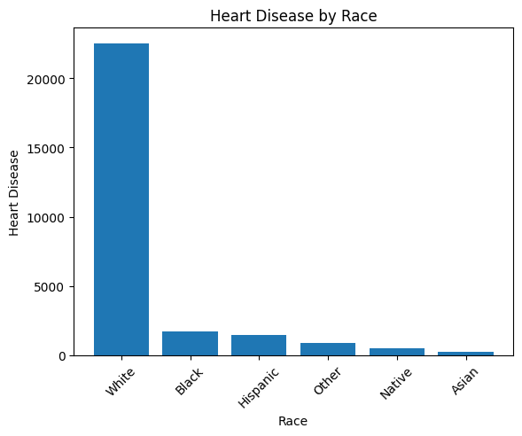

```python
df.loc[df['Race'] == 'American Indian/Alaskan Native', 'Race'] = 'Native'

HeartDisease_Y = df[df['HeartDisease'] == 'Yes']

race = HeartDisease_Y['Race'].value_counts()

plt.bar(x=race.index, height=race.values)
plt.title('Heart Disease by Race')
plt.xlabel('Race')
plt.ylabel('Heart Disease')
plt.xticks(rotation=45)
```

### P-value using the chi2_contingency() function

```python
x = chi2_contingency(con_table)
print(x.pvalue)
```

```
2.9886131565632597e-180
```

### **Conclusion 1 based on Chi-squared test**

Since we are assuming the alpha is 0.05 and our p-value is less than the given alpha value, we will conclude that there is an association between heart disease and race.

## 2. Pearson Correlation test

### **Question**: Is there a linear correlation between BMI and physical health?

### Why are we using the Pearson Correlation test?

The Pearson correlation coefficient (r) is the most common way of measuring a linear correlation. In this test we want to calculates the pairwise correlation coefficients between BMI and physical health. We want to see if they are positive linear relationship, anti-correlated (negative linear relationship) or no linear relationship.

```python
df['BMI'].corr(df['PhysicalHealth'])
```

```
0.10978754360968271
```

Create a plot showing the relationship between BMI, and physical health.

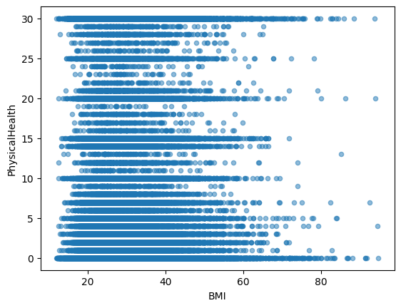

```python
df.plot.scatter("BMI", "PhysicalHealth", alpha = 0.5)
```

### **Conclusion 2 based on Pearson correlation test**

Based on the pearson correlation coeffiencent value we can conclude that there is a some positive linear correlation between BMI and physical health. Since correlation coeffiencent is a positive value greater than 0.

# 3. ANOVA test

### **Question**: Is there a significant difference in BMI between individuals with heart disease and individuals without heart disease?

- HO: There is no significant difference in mean BMI between individuals with heart disease and individuals without heart diseasee.
- HA: There is a significant difference in mean BMI between individuals with heart disease and individuals without heart disease.

### Why are we using the ANOVA test?

We are comparing the mean BMI of individuals with heart disease to those without heart disease. ANOVA is a statistical test designed to analyze the differences among group means in a sample. It allows us to compare the means of BMI across two groups: individuals with heart disease and individuals without heart disease.

```
ANOVA Results for BMI: F_onewayResult(statistic=860.4962832652064, pvalue=6.7794550353687434e-189)
```

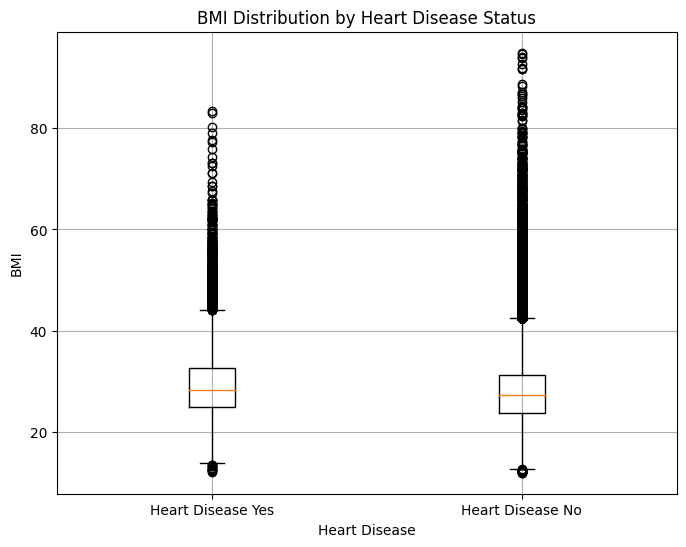

```python
bmi_anova = f_oneway(df[df['HeartDisease'] == "No"]['BMI'],
                     df[df['HeartDisease'] == "Yes"]['BMI'])



print("ANOVA Results for BMI:", bmi_anova)
bmi_heart_disease_yes = df[df['HeartDisease'] == "Yes"]['BMI']
bmi_heart_disease_no = df[df['HeartDisease'] == "No"]['BMI']
plt.figure(figsize=(8, 6))
plt.boxplot([bmi_heart_disease_yes, bmi_heart_disease_no], labels=['Heart Disease Yes', 'Heart Disease No'])
plt.title('BMI Distribution by Heart Disease Status')
plt.xlabel('Heart Disease')
plt.ylabel('BMI')
plt.grid(True)
plt.show()
```

### P-value by applying ANOVA Test

```python
print("p-value:", bmi_anova.pvalue)
```

```
p-value: 6.7794550353687434e-189
```

### **Conclusion 3 based on ANOVA correlation test**

Based on the ANOVA test p value being less than 0.05, we can conclude that there is a significant difference in mean BMI between individuals with heart disease and individuals without heart disease.

### **Insights based on the data Exploration**

1. There is an association between heart disease and race.
2. There is a some positive linear correlation between BMI and physical health.
3. There is a significant difference in mean BMI between individuals with heart disease and individuals without heart disease.

# **Part 4: Machine Learning Model**

```python
models = {
    'KNN': KNeighborsClassifier(),
    'DecisionTree': DecisionTreeClassifier(),
    'LinearRegression': LinearRegression()
}
```

### **1. K-Nearest Neighbors (KNN) Classification**

In this analysis, we applied the K-Nearest Neighbors (KNN) algorithm to a dataset concerning heart disease prediction. After preprocessing the data, which involved encoding categorical variables and scaling the features, we trained a KNN classifier with 5 neighbors. The model was evaluated using a test dataset comprising 30% of the original data.

```python
# Encode categorical variables using LabelEncoder
label_encoder = LabelEncoder()
categorical_columns = df.select_dtypes(include=['object']).columns
for column in categorical_columns:
    df[column] = label_encoder.fit_transform(df[column])

# Split the df into features and target variable
X = df.drop('HeartDisease', axis=1)
y = df['HeartDisease']

# Split the dataset into training and testing sets
X_train, X_test, y_train, y_test = train_test_split(X, y, test_size=0.3, random_state=42)

# Scale the features (important for KNN)
scaler = StandardScaler()
X_train_scaled = scaler.fit_transform(X_train)
X_test_scaled = scaler.transform(X_test)

# Initialize and train the KNN classifier
knn = KNeighborsClassifier(n_neighbors=5)
knn.fit(X_train_scaled, y_train)

# Predictions and evaluation
y_pred = knn.predict(X_test_scaled)
accuracy = accuracy_score(y_test, y_pred)
report = classification_report(y_test, y_pred)

print(f"Accuracy of the KNN model: {accuracy}")
print("Classification Report:")
print(report)
```

```
Accuracy of the KNN model: 0.9049500203254152
Classification Report:
              precision    recall  f1-score   support

           0       0.92      0.98      0.95     87649
           1       0.36      0.13      0.19      8290

    accuracy                           0.90     95939
   macro avg       0.64      0.56      0.57     95939
weighted avg       0.87      0.90      0.88     95939
```

**Test for KNN**

The test aims to evaluate the K-Nearest Neighbors (KNN) classifier's predictive performance on an individual observation with specific features related to heart disease. By manually encoding and scaling these features to the training data, we assess the model's ability to generalize predictions to new, unseen data.

```python
test_data = pd.DataFrame({
    'BMI': [21.63],
    'Smoking': [0],
    'AlcoholDrinking': [0],
    'Stroke': [0],
    'PhysicalHealth': [15],
    'MentalHealth': [0],
    'DiffWalking': [0],
    'Sex': [0],
    'AgeCategory': [9],
    'Race': [4],
    'Diabetic': [0],
    'PhysicalActivity': [1],
    'GenHealth': [1],
    'SleepTime': [4],
    'Asthma': [1],
    'KidneyDisease': [0],
    'SkinCancer': [1]
}, index=[0])

test_data_scaled = scaler.transform(test_data)

# Predict using the trained KNN model
predicted = knn.predict(test_data_scaled)

predicted_outcome = 'Yes' if predicted[0] == 1 else 'No'
print(f"Predicted Heart Disease: {predicted_outcome}")
```

```
Predicted Heart Disease: No
```

## **Visualization for KNN**

**Confusion Matrix**

The confusion matrix is a critical visualization and evaluation tool in machine learning, especially in classification problems. We used it to measure the performance of a machine learning model.

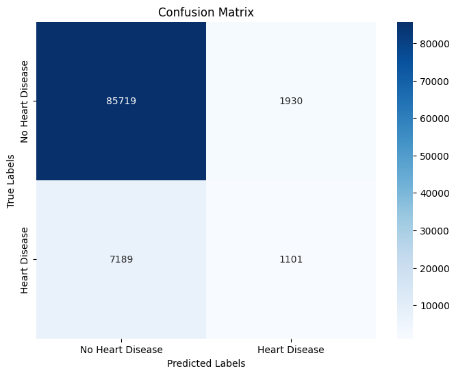

```python
# Confusion Matrix
cm = confusion_matrix(y_test, y_pred)

plt.figure(figsize=(8, 6))
sns.heatmap(cm, annot=True, fmt='d', cmap='Blues', xticklabels=['No Heart Disease', 'Heart Disease'], yticklabels=['No Heart Disease', 'Heart Disease'])
plt.xlabel("Predicted Labels")
plt.ylabel("True Labels")
plt.title("Confusion Matrix")
plt.show()
```

**ROC Curve**

The ROC (Receiver Operating Characteristic) curve is a widely used visualization tool in machine learning for assessing the performance of binary classification models.

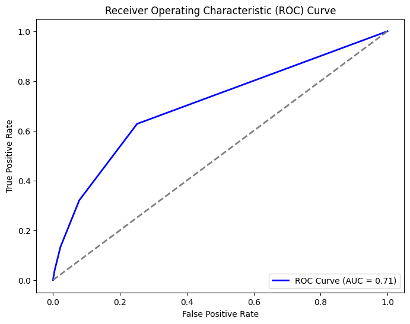

```python
# ROC Curve
y_prob = knn.predict_proba(X_test_scaled)[:, 1]
fpr, tpr, _ = roc_curve(y_test, y_prob)
roc_auc = auc(fpr, tpr)

plt.figure(figsize=(8, 6))
plt.plot(fpr, tpr, color='blue', lw=2, label=f'ROC Curve (AUC = {roc_auc:.2f})')
plt.plot([0, 1], [0, 1], color='gray', lw=2, linestyle='--')
plt.xlabel("False Positive Rate")
plt.ylabel("True Positive Rate")
plt.title("Receiver Operating Characteristic (ROC) Curve")
plt.legend(loc="lower right")
plt.show()
```

**Precision-Recall Curve**

The Precision-Recall (PR) curve is a useful visualization tool in machine learning, especially for binary classification problems where there is a significant class imbalance or when the costs of false positives and false negatives vary distinctly.

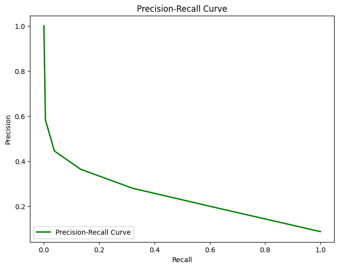

```python
# Precision-Recall Curve
precision, recall, _ = precision_recall_curve(y_test, y_prob)

plt.figure(figsize=(8, 6))
plt.plot(recall, precision, color='green', lw=2, label="Precision-Recall Curve")
plt.xlabel("Recall")
plt.ylabel("Precision")
plt.title("Precision-Recall Curve")
plt.legend(loc="lower left")
plt.show()
```

**Insights about the visualization for KNN**

Based on the results and the visualizations provided by the K-Nearest Neighbors (KNN) model, we can draw several conclusions:

**1. Confusion Matrix:**

- The confusion matrix confirms the imbalance in predictions:
1. True Negatives (correctly predicted 'No Heart Disease') are very high.
2. False Negatives (misclassified 'Heart Disease') are also high, indicating that many 'Heart Disease' cases are classified as 'No Heart Disease'.
3. This imbalance means that the model is not effective in identifying people with heart disease.

**3. Precision-Recall Curve:**

- The Precision-Recall curve illustrates the trade-off between precision and recall for predicting 'Heart Disease'.
- The curve's shape reflects the model's difficulty in predicting 'Heart Disease' cases, with both precision and recall being lower than desired.
- This curve is particularly useful in situations where the minority class is the primary interest, revealing that the model underperforms with 'Heart Disease'.

## **2. Descision Tree**

**Using a decision tree classifier**

Employ the DecisionTreeClassifier from the sklearn.tree module to predict heart disease based on the provided dataset. The decision tree model is initialized, trained on a training set, and then used to make predictions on a test set to evaluate its accuracy and performance in predicting heart disease.

```python
# Encode categorical variables using LabelEncoder
label_encoder = LabelEncoder()
categorical_columns = df.select_dtypes(include=['object']).columns
for column in categorical_columns:
    df[column] = label_encoder.fit_transform(df[column])

# Split the df into features and target variable
X = df.drop('HeartDisease', axis=1)
y = df['HeartDisease']

# Split the dataset into training and testing sets
X_train, X_test, y_train, y_test = train_test_split(X, y, test_size=0.3, random_state=42)

# Initialize and train the Decision Tree classifier
decision_tree = DecisionTreeClassifier(random_state=42)
decision_tree.fit(X_train, y_train)

# Predictions and evaluation
y_pred = decision_tree.predict(X_test)
accuracy = accuracy_score(y_test, y_pred)
report = classification_report(y_test, y_pred)

print(f"Accuracy of the Decision Tree model: {accuracy}")
print("Classification Report:")
print(report)
```

```
Accuracy of the Decision Tree model: 0.8631630515223214
Classification Report:
              precision    recall  f1-score   support

           0       0.93      0.92      0.92     87649
           1       0.23      0.25      0.24      8290

    accuracy                           0.86     95939
   macro avg       0.58      0.59      0.58     95939
weighted avg       0.87      0.86      0.87     95939
```

## **Visualization** **for** **Decision trees**

**Feature** **Importance**

Feature importance visualization is a key technique in machine learning that helps to interpret the contributions of different variables (features) to the prediction model. It provides insights into the dataset and the model’s behavior, which can guide further model development and decision-making.

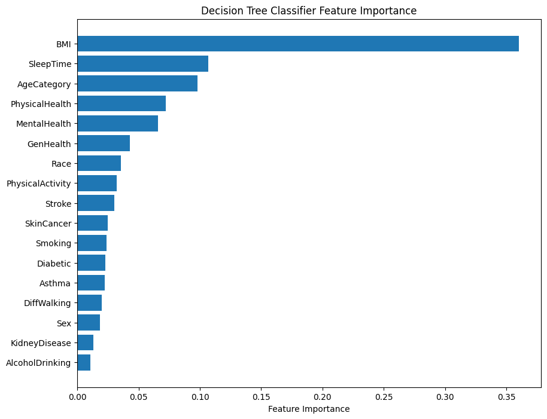

```python
# Feature Importance
feature_importance = decision_tree.feature_importances_
sorted_idx = np.argsort(feature_importance)

plt.figure(figsize=(10, 8))
plt.barh(range(X.shape[1]), feature_importance[sorted_idx], align='center')
plt.yticks(range(X.shape[1]), X.columns[sorted_idx])
plt.xlabel("Feature Importance")
plt.title("Decision Tree Classifier Feature Importance")
plt.show()
```

**Confusion Matrix**

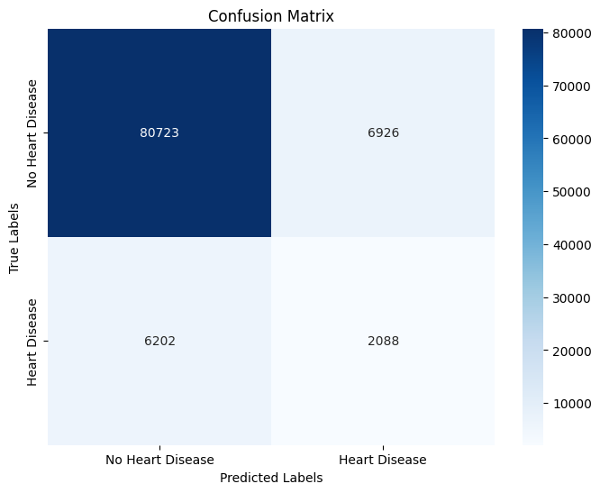

```python
# Confusion Matrix
cm = confusion_matrix(y_test, y_pred)

plt.figure(figsize=(8, 6))
sns.heatmap(cm, annot=True, fmt='d', cmap='Blues', xticklabels=['No Heart Disease', 'Heart Disease'], yticklabels=['No Heart Disease', 'Heart Disease'])
plt.xlabel("Predicted Labels")
plt.ylabel("True Labels")
plt.title("Confusion Matrix")
plt.show()
```

**ROC Curve**

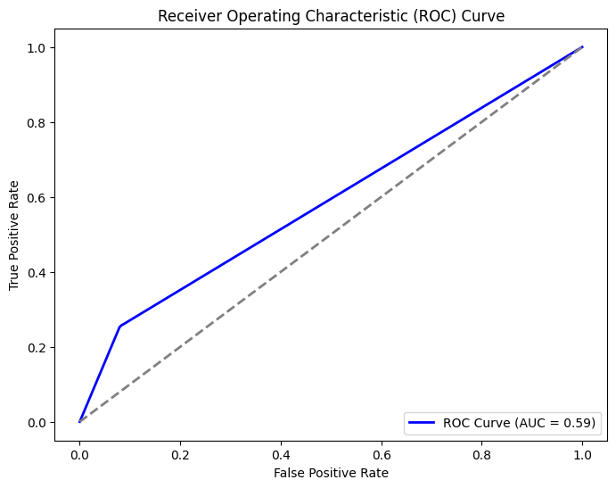

```python
# ROC Curve
y_prob = decision_tree.predict_proba(X_test)[:, 1]
fpr, tpr, _ = roc_curve(y_test, y_prob)
roc_auc = auc(fpr, tpr)

plt.figure(figsize=(8, 6))
plt.plot(fpr, tpr, color='blue', lw=2, label=f'ROC Curve (AUC = {roc_auc:.2f})')
plt.plot([0, 1], [0, 1], color='gray', lw=2, linestyle='--')
plt.xlabel("False Positive Rate")
plt.ylabel("True Positive Rate")
plt.title("Receiver Operating Characteristic (ROC) Curve")
plt.legend(loc="lower right")
plt.show()
```

**Insights for the vizualization of the decision tree**

1. Classification Report:
2. Accuracy: An overall accuracy of 86.3% suggests that the Decision Tree model performs reasonably well.
3. Class Imbalance:
- 'No Heart Disease' (Class 0) has high precision and recall, meaning that the model effectively identifies people without heart disease.
- 'Heart Disease' (Class 1) has low precision and recall, indicating that many people with heart disease are misclassified as not having it (high false negatives).

The macro average and weighted average scores reveal this imbalance, as the macro average F1 score is significantly lower than the weighted average.

**3. Feature Importance**:

- The feature importance bar plot shows which features were most influential in the model's predictions.
- Key features like 'BMI', 'AgeCategory', and 'PhysicalHealth' were crucial in predicting heart disease.
- The insights from this graph can help medical professionals identify which factors significantly contribute to heart disease predictions.
- List item

**Applying a decision tree for a binary classification**

```python
# Encode categorical variables using LabelEncoder
label_encoder = LabelEncoder()
categorical_columns = df.select_dtypes(include=['object']).columns
for column in categorical_columns:
    df[column] = label_encoder.fit_transform(df[column])

# Split the df into features and target variable
X = df.drop('HeartDisease', axis=1)
y = df['HeartDisease']

# Split the dataset into training and testing sets
X_train, X_test, y_train, y_test = train_test_split(X, y, test_size=0.3, random_state=42)

# Initialize and train the Decision Tree classifier
decision_tree = DecisionTreeClassifier(random_state=42)
decision_tree.fit(X_train, y_train)

# Predictions and evaluation
y_pred = decision_tree.predict(X_test)
accuracy = accuracy_score(y_test, y_pred)
report = classification_report(y_test, y_pred)

print(f"Accuracy of the Decision Tree model: {accuracy}")
print("Classification Report:")
print(report)
```

```
Accuracy of the Decision Tree model: 0.8631630515223214
Classification Report:
              precision    recall  f1-score   support

           0       0.93      0.92      0.92     87649
           1       0.23      0.25      0.24      8290

    accuracy                           0.86     95939
   macro avg       0.58      0.59      0.58     95939
weighted avg       0.87      0.86      0.87     95939
```

### **Test : Decision Trees for a binary classification**

The test aims to evaluate the Decision Tree classifier's predictive performance on an individual observation with specific features related to heart disease. By manually encoding and scaling these features to the training data, we assess the model's ability to generalize predictions to new, unseen data.

```python
test_data = pd.DataFrame({
    'BMI': [23.71],
    'Smoking': [0],
    'AlcoholDrinking': [0],
    'Stroke': [0],
    'PhysicalHealth': [28],
    'MentalHealth': [0],
    'DiffWalking': [1],
    'Sex': [0],
    'AgeCategory': [5],
    'Race': [5],
    'Diabetic': [0],
    'PhysicalActivity': [1],
    'GenHealth': [4],
    'SleepTime': [8],
    'Asthma': [0],
    'KidneyDisease': [0],
    'SkinCancer': [0]
}, index=[0])

# Make a prediction
predicted = decision_tree.predict(test_data)

# Display the prediction as "Yes" or "No"
predicted_outcome = 'Yes' if predicted[0] == 1 else 'No'
print(f"Predicted Heart Disease: {predicted_outcome}")
```

```
Predicted Heart Disease: No
```

## **3. Logistic Regression**

The Logistic Regression model is used to forecast the occurrence of heart disease using the heart disease dataset. The model is set up and trained on a designated training set. It is used to make predictions, allowing for the assessment of its accuracy and effectiveness in predicting heart disease.

```python
# Encode categorical variables using LabelEncoder
label_encoder = LabelEncoder()
categorical_columns = df.select_dtypes(include=['object']).columns
for column in categorical_columns:
    df[column] = label_encoder.fit_transform(df[column])

# Split the df into features and target variable
X = df.drop('HeartDisease', axis=1)
y = df['HeartDisease']

# Split the dataset into training and testing sets
X_train, X_test, y_train, y_test = train_test_split(X, y, test_size=0.3, random_state=42)

# Initialize and train the Logistic Regression model with max_iter=400 (need for no convergence warning)
logistic_regression = LogisticRegression(max_iter=400)
logistic_regression.fit(X_train, y_train)

# Predictions and evaluation
y_pred = logistic_regression.predict(X_test)
accuracy = accuracy_score(y_test, y_pred)
report = classification_report(y_test, y_pred)

print("Accuracy of the Logistic Regression model:", accuracy)
print("Classification Report:")
print(report)
```

```
Accuracy of the Logistic Regression model: 0.9137993933645338
Classification Report:
              precision    recall  f1-score   support

           0       0.92      0.99      0.95     87649
           1       0.51      0.09      0.15      8290

    accuracy                           0.91     95939
   macro avg       0.71      0.54      0.55     95939
weighted avg       0.88      0.91      0.89     95939
```

## **Visualization** **for** **Logistic Regression**

**Confusion Matrix**

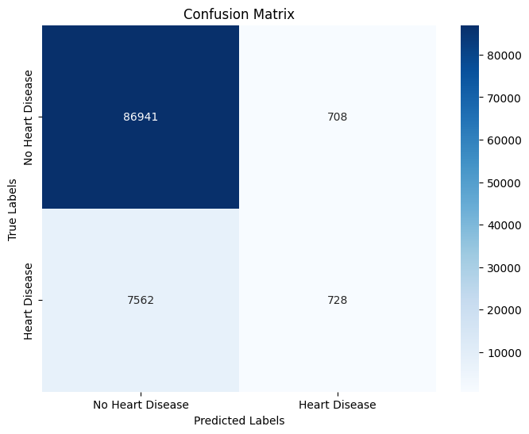

```python
# Visualize Confusion Matrix
cm = confusion_matrix(y_test, y_pred)

plt.figure(figsize=(8, 6))
sns.heatmap(cm, annot=True, fmt='d', cmap='Blues', xticklabels=['No Heart Disease', 'Heart Disease'], yticklabels=['No Heart Disease', 'Heart Disease'])
plt.xlabel("Predicted Labels")
plt.ylabel("True Labels")
plt.title("Confusion Matrix")
plt.show()
```

**ROC Curve**

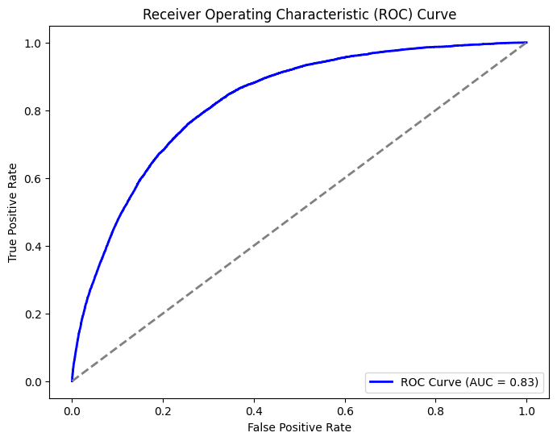

```python
# Calculate predicted probabilities for logistic regression
y_prob_logistic_regression = logistic_regression.predict_proba(X_test)[:, 1]
# Calculate false positive rate and true positive rate
fpr_logistic_regression, tpr_logistic_regression, _ = roc_curve(y_test, y_prob_logistic_regression)
# Calculate AUC
roc_auc_logistic_regression = auc(fpr_logistic_regression, tpr_logistic_regression)
# Plot ROC Curve
plt.figure(figsize=(8, 6))
plt.plot(fpr_logistic_regression, tpr_logistic_regression, color='blue', lw=2, label=f'ROC Curve (AUC = {roc_auc_logistic_regression:.2f})')
plt.plot([0, 1], [0, 1], color='gray', lw=2, linestyle='--')
plt.xlabel("False Positive Rate")
plt.ylabel("True Positive Rate")
plt.title("Receiver Operating Characteristic (ROC) Curve")
plt.legend(loc="lower right")
plt.show()
```

**Precision-Recall Curve**

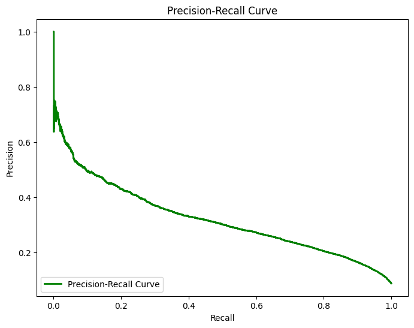

```python
precision, recall, _ = precision_recall_curve(y_test, y_prob_logistic_regression)

plt.figure(figsize=(8, 6))
plt.plot(recall, precision, color='green', lw=2, label="Precision-Recall Curve")
plt.xlabel("Recall")
plt.ylabel("Precision")
plt.title("Precision-Recall Curve")
plt.legend(loc="lower left")
plt.show()
```

## Visualization Insights of Logistic Regression

**ROC Curve:** The data represented in the ROC Curve represents the trade-off between the true positive rate and the false positive rate. In the graph, the AUC is 0.83, indicating that the model has a good discrimination ability and performs well in distinguishing between positive and negative instances (heart disease)

**Precision Recall Curve:** The data represented in the Precision Recall Curve represents the trade-off between precision and recall at different classification thresholds. In this representation, the low area under the curve shows that the model does not perform well considering trade-offs between precision and recall, which can be inferred by its low true positive rate.

### **Insights based on the data Exploration**

1. **KNN**: The KNN model shows high predictive performance in identifying cases without heart disease. However, due to class imbalance, the model struggles with identifying heart disease cases, as evidenced by poor precision and recall for this class. This issue could be addressed through data balancing techniques (e.g., oversampling the minority class or undersampling the majority class), feature selection, or tuning KNN parameters.
2. **Decision Tree**: The Decision Tree model has moderate accuracy and effectively identifies people without heart disease. However, its relatively low precision and recall for 'Heart Disease' reflect poor prediction performance on this minority class. Strategies to address these issues could include tuning hyperparameters, using ensemble methods like Random Forests, or employing techniques to handle class imbalance, such as data resampling or changing the decision criterion thresholds.
3. **Logistic Regression**: The Logistic Regression model shows a high accuracy in predicting cases without heart disease. It performs poorly with predicting those with heart disease. It can be improved with addressing the class imbalance (oversampling of cases with heart disease), fine tuning hyperparameters, and techniques such as bagging (eg.Random Forest) or boosting (eg. Gradient Boosting) to combine multiple weak classifiers to build a stronger model

# **Part 5: Conclusion about the Dataset**

Based on the description provided and insights from machine learning analysis using the heart disease dataset, several observations and characteristics about the data can be highlighted:

**1. Class Imbalance:** A predominant issue with the dataset is the imbalance between the classes—specifically, the number of cases without heart disease far exceeds the number of cases with heart disease. This imbalance affects the performance of various machine learning models, particularly in their ability to accurately predict less frequent cases of heart disease.

**2. Diverse Demographic Data:** The dataset includes a wide range of demographic variables such as age, sex, and race. This diversity allows for a comprehensive analysis of how heart disease affects different demographic groups and can help in identifying high-risk populations.

**3. Lifestyle and Health Variables:** It encompasses key lifestyle and health-related variables such as smoking, alcohol consumption, physical activity, BMI (Body Mass Index), and comorbid conditions like diabetes, stroke, and kidney disease. These features are crucial for analyzing the risk factors associated with heart disease and provide a holistic view of potential preventive strategies.

**4. Predictive Analysis Capability:** Despite challenges, the dataset supports predictive analysis for heart disease, as shown by the application of models like KNN, Decision Trees, and Logistic Regression. While these models perform well in predicting non-disease cases due to class distribution, they reveal the necessity for more sophisticated handling of imbalanced data to improve disease prediction.

**5. Need for Advanced Analytical Techniques:** The initial analysis indicates a need for advanced data handling techniques such as resampling methods, enhanced feature selection, and ensemble learning approaches. These techniques could mitigate issues like class imbalance and improve the models' predictive accuracy for the minority class.

**6. Potential for Impactful Insights:** The dataset holds the potential to provide impactful insights into the prevention and management of heart disease. By identifying key risk factors and their prevalence across different demographic groups, the data can inform targeted public health strategies and interventions.

**7. Opportunities for Model Improvement:** There are significant opportunities to refine the machine learning models used in the analysis. Strategies like adjusting model parameters, exploring more complex models, or employing hybrid approaches could provide better outcomes in terms of model sensitivity and specificity.

**8. Ethical Considerations:** Given the sensitivity of medical data and the implications of predictive modeling in healthcare, ethical considerations must be taken into account. This includes ensuring the privacy of individuals' data, addressing potential biases in the dataset, and responsibly communicating the limitations and uncertainties of model predictions.

Overall, the heart disease dataset is a rich source of information that, if analyzed correctly, can substantially contribute to understanding heart disease dynamics, influencing both clinical practices and public health policies. Addressing its challenges and leveraging its potential will be crucial for deriving reliable and actionable insights.